Commit containing full submission  
1) Code for reading in the dataset and/or processing the data  
2) Histogram of the total number of steps taken each day  
3) Mean and median number of steps taken each day  
4) Time series plot of the average number of steps taken  
5) The 5 minute interval that, on average, contains the maximum number of steps  
6) Code to describe and show a strategy for imputing missing data  
7) Histogram of the total number of steps taken each day after missing values are imputed  
8) Panel plot comparing the average number of steps taken per 5 minute interval across weekdays and weekends  
9) All of the R code needed to reproduce the results (numbers, plots, etc) in the report

```r
# Install packages
library(dplyr)
library(lubridate)
```

```r
library(ggplot2)
library(scales)
library(knitr)
# Read in data
df <- read.csv("activity.csv",
               na.strings = c("NA",""),
               sep = ",", strip.white = TRUE,
               colClasses = "character")

# Examine the structure
str(df)
```

```
## 'data.frame':    17568 obs. of  3 variables:
##  $ steps   : chr  NA NA NA NA ...
##  $ date    : chr  "2012-10-01" "2012-10-01" "2012-10-01" "2012-10-01" ...
##  $ interval: chr  "0" "5" "10" "15" ...
```

```r
# Change class of objects
df$date <- ymd(df$date)
df$steps <- as.numeric(df$steps)
df$interval <- as.numeric(df$interval)
```

```r
# Create a new unique date field

# Add leading zeros to the interval field
df$newInterval <- sprintf("%04d", df$interval)

# Combine the new interval field (which is in military time for minutes and seconds)...
# ...with the date field
df$newDate <- paste(df$date, df$newInterval, sep = " ")

# Change this new field to date format
df$newDate <- parse_date_time(df$newDate, "ymd hm")

head(df, 6)
```

```
##   steps       date interval newInterval             newDate
## 1    NA 2012-10-01        0        0000 2012-10-01 00:00:00
## 2    NA 2012-10-01        5        0005 2012-10-01 00:05:00
## 3    NA 2012-10-01       10        0010 2012-10-01 00:10:00
## 4    NA 2012-10-01       15        0015 2012-10-01 00:15:00
## 5    NA 2012-10-01       20        0020 2012-10-01 00:20:00
## 6    NA 2012-10-01       25        0025 2012-10-01 00:25:00
```

```r
# Add a field for day of Week
df$dayOfWeek <- weekdays(df$date)

# Add columns that extract the hours and minutes from the date field
df$hrs <- hour(df$newDate)
df$mins <- minute(df$newDate)

# Create a new column with unique hour-minute combo
df$hoursMinutes <- paste(df$hrs, df$mins, sep = " : ")

head(df,6)
```

```
##   steps       date interval newInterval             newDate dayOfWeek hrs
## 1    NA 2012-10-01        0        0000 2012-10-01 00:00:00    Monday   0
## 2    NA 2012-10-01        5        0005 2012-10-01 00:05:00    Monday   0
## 3    NA 2012-10-01       10        0010 2012-10-01 00:10:00    Monday   0
## 4    NA 2012-10-01       15        0015 2012-10-01 00:15:00    Monday   0
## 5    NA 2012-10-01       20        0020 2012-10-01 00:20:00    Monday   0
## 6    NA 2012-10-01       25        0025 2012-10-01 00:25:00    Monday   0
##   mins hoursMinutes
## 1    0        0 : 0
## 2    5        0 : 5
## 3   10       0 : 10
## 4   15       0 : 15
## 5   20       0 : 20
## 6   25       0 : 25
```

```r
# Summarise overall

pacesSummary <- df %>%
    summarise(stepsTaken = sum(steps, na.rm = TRUE), # Total number of steps taken
              days = n_distinct(date), # Total number of days
              avgStepsPerDay = stepsTaken / days, # Total steps divided by total days
              avgStepsPerHour = avgStepsPerDay / 24, # Steps/day divided by 24 hours
              avgStepsPer5minInterval = avgStepsPerHour / 12) # There are 12, 5-minute intervals in an hour
# Round
pacesSummary$avgStepsPerDay <- round(pacesSummary$avgStepsPerDay, digits = 2)
pacesSummary$avgStepsPerHour <- round(pacesSummary$avgStepsPerHour, digits = 2)
pacesSummary$avgStepsPer5minInterval <- round(pacesSummary$avgStepsPer5minInterval, digits = 2)

head(pacesSummary)
```

```
##   stepsTaken days avgStepsPerDay avgStepsPerHour avgStepsPer5minInterval
## 1     570608   61        9354.23          389.76                   32.48
```

```r
# Group by date and then summarise for each day
dailyPaces <- df %>%
    group_by(date) %>%
    summarise(dailyEntries = n(),
              inactive = sum(steps == 0),
              active = sum(!steps == 0),
              percentActive = active / dailyEntries,
              totalSteps = sum(steps, na.rm = TRUE),
              avgStepsPer5minInterval = mean(steps, na.rm = TRUE),
              avgStepsPerHour = totalSteps / 24,
              avgStepsPerDay = mean(steps, na.rm = TRUE))

# Round
dailyPaces$avgStepsPer5minInterval <- round(dailyPaces$avgStepsPer5minInterval, digits = 2)
dailyPaces$avgStepsPerHour <- round(dailyPaces$avgStepsPerHour, digits = 2)
dailyPaces$avgStepsPerDay <- round(dailyPaces$avgStepsPerDay, digits = 2)
dailyPaces$percentActive <- round(dailyPaces$percentActive, digits = 2)

head(dailyPaces, 6)
```

```
## Source: local data frame [6 x 9]
##
##         date dailyEntries inactive active percentActive totalSteps
##       (time)        (int)    (int)  (int)         (dbl)      (dbl)
## 1 2012-10-01          288       NA     NA            NA          0
## 2 2012-10-02          288      286      2          0.01        126
## 3 2012-10-03          288      207     81          0.28      11352
## 4 2012-10-04          288      188    100          0.35      12116
## 5 2012-10-05          288      202     86          0.30      13294
## 6 2012-10-06          288      182    106          0.37      15420
## Variables not shown: avgStepsPer5minInterval (dbl), avgStepsPerHour (dbl),
##   avgStepsPerDay (dbl)
```

```r
#     1. Calculate the total number of steps taken per day
stepsEachDay <- dailyPaces$totalSteps # numeric vector of length 61
```

```r
# Calculate and and report the mean and median of the total number of steps taken per day
medianSteps <- median(stepsEachDay) # 10,395

# Calculate total steps taken
totalSteps <- pacesSummary$stepsTaken # 570,608

# Calculate mean steps taken (Total Steps / Days) each day
meanSteps <- totalSteps / 61 # 9,354.229...

# Calulate the mean steps per 5 minute interval:
# TotalSteps divided by 61 days divided by 24 hours divided by 60 minutes divided by 12 measurements per hour
avgStepsPer5mins <- ((((totalSteps / 61) / 24) / 60) / 12) # 0.54133
```

```r
# Change steps each day to data frame
stepsEachDay <- as.data.frame(stepsEachDay)

# Name the column "Steps"
colnames(stepsEachDay) <- "Steps"
```

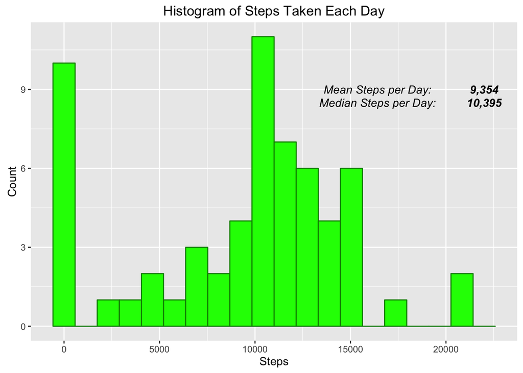

```r
#     2. Make a histogram of the total number of steps taken each day
ggplot(stepsEachDay, aes(Steps)) +
    geom_histogram(bins = 20, color = "green4", fill = "green") +
    annotate(geom = "text", label = "Mean Steps per Day: ", x = 16500, y = 9, fontface = "italic") +
    annotate(geom = "text", label = "Median Steps per Day: ", x = 16500, y = 8.5, fontface = "italic") +
    annotate(geom = "text", label = comma(round(meanSteps, digits = 0)), x = 22000, y = 9, fontface = "bold.italic") +
    annotate(geom = "text", label = comma(medianSteps), x = 22000, y = 8.5, fontface = "bold.italic")+
    ggtitle("Histogram of Steps Taken Each Day") +
    labs(x = "Steps", y = "Count")
```

WHAT IS THE AVERAGE DAILY ACTIVITY PATTERN?

```r
# Select only necessary columns for joining
daily1 <- dailyPaces[, c(1,7)] # The Date field and the Avg Steps per 5-minute interval field

head(daily1, 6)
```

```
## Source: local data frame [6 x 2]
##
##         date avgStepsPer5minInterval
##       (time)                   (dbl)
## 1 2012-10-01                     NaN
## 2 2012-10-02                    0.44
## 3 2012-10-03                   39.42
## 4 2012-10-04                   42.07
## 5 2012-10-05                   46.16
## 6 2012-10-06                   53.54
```

```r
# Add a column to the original data frame that includes the average steps for that day
df1 <- left_join(df, daily1, by = "date")

head(df1, 6)
```

```
##   steps       date interval newInterval             newDate dayOfWeek hrs
## 1    NA 2012-10-01        0        0000 2012-10-01 00:00:00    Monday   0
## 2    NA 2012-10-01        5        0005 2012-10-01 00:05:00    Monday   0
## 3    NA 2012-10-01       10        0010 2012-10-01 00:10:00    Monday   0
## 4    NA 2012-10-01       15        0015 2012-10-01 00:15:00    Monday   0
## 5    NA 2012-10-01       20        0020 2012-10-01 00:20:00    Monday   0
## 6    NA 2012-10-01       25        0025 2012-10-01 00:25:00    Monday   0
##   mins hoursMinutes avgStepsPer5minInterval
## 1    0        0 : 0                     NaN
## 2    5        0 : 5                     NaN
## 3   10       0 : 10                     NaN
## 4   15       0 : 15                     NaN
## 5   20       0 : 20                     NaN
## 6   25       0 : 25                     NaN
```

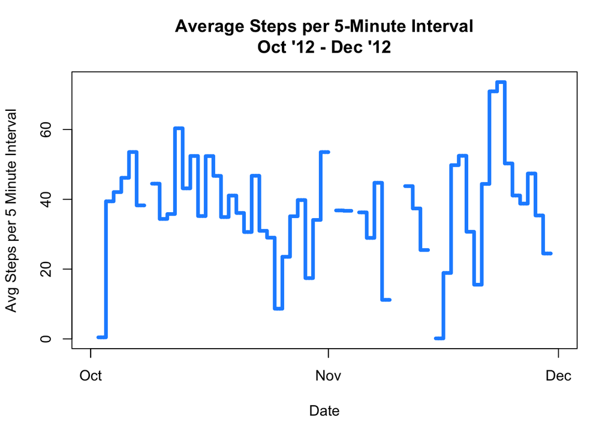

```r
#     1. Make a times series plot (i.e., type = "l") of the 5-minute interval (x-axis) and
#        the average number of steps taken, averaged across all days (y-axis)
par(mfrow = c(1,1))
plot(df1$newDate, df1$avgStepsPer5minInterval,
     type = "l",
     col = "dodgerblue",
     lwd = 4,
     main = "Average Steps per 5-Minute Interval\nOct '12 - Dec '12",
     xlab ="Date",
     ylab = "Avg Steps per 5 Minute Interval")
```

```r
#     2. Which 5-minute interval, on average across all the days in the dataset, contains the maximum number of steps?
busiestFiveMins <- df %>%
    group_by(hoursMinutes) %>%
    summarise(stepsTaken = sum(steps, na.rm = TRUE)) %>%
    arrange(desc(stepsTaken)) %>%
    head(1) # 8:35am

head(busiestFiveMins)
```

```
## Source: local data frame [1 x 2]
##
##   hoursMinutes stepsTaken
##          (chr)      (dbl)
## 1       8 : 35      10927
```

**So the busiest five minutes of steps is at 8:35am**

```r
#     1. Calculate and report the total number of missing values (NA's) in the dataset
totalMissing <- sum(is.na(df$steps)) %>% print # 2,304
```

```
## [1] 2304
```

**The total number of missing values (NAs) in the dataset is 2,304**

Devise a strategy for filling in all of the missing values in the dataset. The strategy does not need to be sophisticated.

[output not shown]

```r
#    3. Create a new dataset that is equal to the original dataset but with the missing data filled in.
newDataset <- df

head(newDataset, 6)
```

```
##   steps       date interval newInterval             newDate dayOfWeek hrs
## 1    NA 2012-10-01        0        0000 2012-10-01 00:00:00    Monday   0
## 2    NA 2012-10-01        5        0005 2012-10-01 00:05:00    Monday   0
## 3    NA 2012-10-01       10        0010 2012-10-01 00:10:00    Monday   0
## 4    NA 2012-10-01       15        0015 2012-10-01 00:15:00    Monday   0
## 5    NA 2012-10-01       20        0020 2012-10-01 00:20:00    Monday   0
## 6    NA 2012-10-01       25        0025 2012-10-01 00:25:00    Monday   0
##   mins hoursMinutes
## 1    0        0 : 0
## 2    5        0 : 5
## 3   10       0 : 10
## 4   15       0 : 15
## 5   20       0 : 20
## 6   25       0 : 25
```

```r
# Fill in missing values with the overall average steps per 5-minute interval
newDataset$steps[is.na(newDataset$steps)] <- avgStepsPer5mins

head(newDataset, 6)
```

```
##       steps       date interval newInterval             newDate dayOfWeek
## 1 0.5413327 2012-10-01        0        0000 2012-10-01 00:00:00    Monday
## 2 0.5413327 2012-10-01        5        0005 2012-10-01 00:05:00    Monday
## 3 0.5413327 2012-10-01       10        0010 2012-10-01 00:10:00    Monday
## 4 0.5413327 2012-10-01       15        0015 2012-10-01 00:15:00    Monday
## 5 0.5413327 2012-10-01       20        0020 2012-10-01 00:20:00    Monday
## 6 0.5413327 2012-10-01       25        0025 2012-10-01 00:25:00    Monday
##   hrs mins hoursMinutes
## 1   0    0        0 : 0
## 2   0    5        0 : 5
## 3   0   10       0 : 10
## 4   0   15       0 : 15
## 5   0   20       0 : 20
## 6   0   25       0 : 25
```

4. Make a histogram of the total number of steps taken each day and Calculate and report the MEAN and MEDIAN total number of steps taken per day. Do these values differ from the estimates from the first part of this assignment? What is the impact of imputing missing data on the estimates of the total daily number of steps?

Summarise overall again

```r
pacesSummary1 <- newDataset %>%
    summarise(stepsTaken = sum(steps, na.rm = TRUE), # Total number of steps taken
              days = n_distinct(date), # Total number of days
              avgStepsPerDay = stepsTaken / days, # Total steps divided by total days
              avgStepsPerHour = avgStepsPerDay / 24, # Steps/day divided by 24 hours
              avgStepsPer5minInterval = avgStepsPerHour / 12) # There are 12, 5-minute intervals in an hour
# Round
pacesSummary1$avgStepsPerDay <- round(pacesSummary1$avgStepsPerDay, digits = 2)
pacesSummary1$avgStepsPerHour <- round(pacesSummary1$avgStepsPerHour, digits = 2)
pacesSummary1$avgStepsPer5minInterval <- round(pacesSummary1$avgStepsPer5minInterval, digits = 2)


head(pacesSummary1, 6)
```

```
##   stepsTaken days avgStepsPerDay avgStepsPerHour avgStepsPer5minInterval
## 1   571855.2   61        9374.68          390.61                   32.55
```

```r
# Group by date to summarise for each day
dailyPaces1 <- newDataset %>%
    group_by(date) %>%
    summarise(dailyEntries = n(),
              inactive = sum(steps == 0),
              active = sum(!steps == 0),
              percentActive = active / dailyEntries,
              totalSteps = sum(steps, na.rm = TRUE),
              avgStepsPer5minInterval = mean(steps, na.rm = TRUE),
              avgStepsPerHour = totalSteps / 24,
              avgStepsPerDay = mean(steps, na.rm = TRUE))

# Round
dailyPaces1$avgStepsPer5minInterval <- round(dailyPaces1$avgStepsPer5minInterval, digits = 2)
dailyPaces1$avgStepsPerHour <- round(dailyPaces1$avgStepsPerHour, digits = 2)
dailyPaces1$avgStepsPerDay <- round(dailyPaces1$avgStepsPerDay, digits = 2)
dailyPaces1$percentActive <- round(dailyPaces1$percentActive, digits = 2)

head(dailyPaces1, 6)
```

```
## Source: local data frame [6 x 9]
##
##         date dailyEntries inactive active percentActive totalSteps
##       (time)        (int)    (int)  (int)         (dbl)      (dbl)
## 1 2012-10-01          288        0    288          1.00   155.9038
## 2 2012-10-02          288      286      2          0.01   126.0000
## 3 2012-10-03          288      207     81          0.28 11352.0000
## 4 2012-10-04          288      188    100          0.35 12116.0000
## 5 2012-10-05          288      202     86          0.30 13294.0000
## 6 2012-10-06          288      182    106          0.37 15420.0000
## Variables not shown: avgStepsPer5minInterval (dbl), avgStepsPerHour (dbl),
##   avgStepsPerDay (dbl)
```

```r
#     1. Calculate the total number of steps taken per day
stepsEachDay2 <- dailyPaces1$totalSteps # numeric vector of length 61
```

Calculate and and report the mean and median of the total number of steps taken per day

```r
# Calculate the median
medianSteps2 <- median(stepsEachDay2) # 10,395... Same as before

# Calculate total steps taken
totalSteps2 <- pacesSummary1$stepsTaken # was 570,608 now is 571,855

# Calculate mean steps taken (Total Steps / Days) each day
meanSteps2 <- totalSteps2 / 61 # 9,354.2... changed to 9,374.7, up 20 steps per day
```

Calulate the mean steps per 5 minute interval:

[output not shown]

```r
# Change steps each day into a data frame
stepsEachDay2 <- as.data.frame(dailyPaces1$totalSteps) # data frame with 61 observations

colnames(stepsEachDay2) <- "Steps"
```

2. Make a histogram of the total number of steps taken each day and Calculate and report the MEAN and MEDIAN  
   total number of steps taken per day.

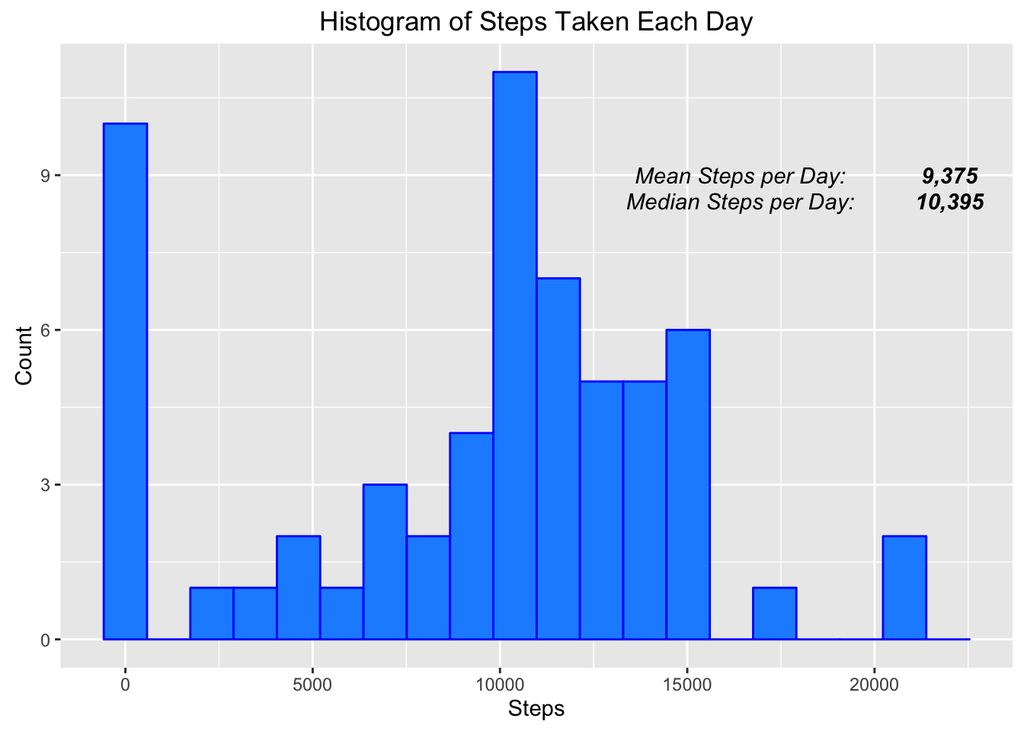

```r
ggplot(stepsEachDay2, aes(Steps)) +
    geom_histogram(bins = 20, color = "blue", fill = "dodgerblue") +
    annotate(geom = "text", label = "Mean Steps per Day: ", x = 16500, y = 9, fontface = "italic") +
    annotate(geom = "text", label = "Median Steps per Day: ", x = 16500, y = 8.5, fontface = "italic") +
    annotate(geom = "text", label = comma(round(meanSteps2, digits = 0)), x = 22000, y = 9, fontface = "bold.italic") +
    annotate(geom = "text", label = comma(medianSteps2), x = 22000, y = 8.5, fontface = "bold.italic")+
    ggtitle("Histogram of Steps Taken Each Day") +
    labs(x = "Steps", y = "Count")
```

ARE THERE DIFFERENCES IN ACTIVITY PATTERNS BETWEEN WEEKDAYS AND WEEKENDS?  
(the weekdays() function may help. Use the filled-in dataset)

1. Create a nuew factor variable in the dataset with two levels - “weekday” and “weekend” - indicating whether a given date is a weekday or weekend day.

```r
# Create a weekdays vector and a weekends vector
weekdays <- c("Monday","Tuesday","Wednesday","Thursday","Friday")

# Use ifelse() function to add new column
df$dayType <- ifelse(df$dayOfWeek %in% weekdays, "weekday","weekend")

#Change new column to a factor
df$dayType <- factor(df$dayType, levels = c("weekday","weekend"))

head(df, 6)
```

```
##   steps       date interval newInterval             newDate dayOfWeek hrs
## 1    NA 2012-10-01        0        0000 2012-10-01 00:00:00    Monday   0
## 2    NA 2012-10-01        5        0005 2012-10-01 00:05:00    Monday   0
## 3    NA 2012-10-01       10        0010 2012-10-01 00:10:00    Monday   0
## 4    NA 2012-10-01       15        0015 2012-10-01 00:15:00    Monday   0
## 5    NA 2012-10-01       20        0020 2012-10-01 00:20:00    Monday   0
## 6    NA 2012-10-01       25        0025 2012-10-01 00:25:00    Monday   0
##   mins hoursMinutes dayType
## 1    0        0 : 0 weekday
## 2    5        0 : 5 weekday
## 3   10       0 : 10 weekday
## 4   15       0 : 15 weekday
## 5   20       0 : 20 weekday
## 6   25       0 : 25 weekday
```

```r
# Group by Day Type and Day of week and summarise to find mean for each
dayTypeSummary2 <- df %>%
    group_by(dayOfWeek) %>%
    summarise(dailyEntries = n(),
              totalSteps = sum(steps, na.rm = TRUE),
              avgStepsPer5minInterval = mean(steps, na.rm = TRUE),
              avgStepsPerHour = totalSteps / 24)



# Select columns
dayTypeSummary2 <- dayTypeSummary2[, c(1,4)]

head(dayTypeSummary2, 6)
```

```
## Source: local data frame [6 x 2]
##
##   dayOfWeek avgStepsPer5minInterval
##       (chr)                   (dbl)
## 1    Friday                42.91567
## 2    Monday                34.63492
## 3  Saturday                43.52579
## 4    Sunday                42.63095
## 5  Thursday                28.51649
## 6   Tuesday                31.07485
```

```r
# Join with original data frame
df3 <- left_join(df, dayTypeSummary2, by = "dayOfWeek")

head(df3, 6)
```

```
##   steps       date interval newInterval             newDate dayOfWeek hrs
## 1    NA 2012-10-01        0        0000 2012-10-01 00:00:00    Monday   0
## 2    NA 2012-10-01        5        0005 2012-10-01 00:05:00    Monday   0
## 3    NA 2012-10-01       10        0010 2012-10-01 00:10:00    Monday   0
## 4    NA 2012-10-01       15        0015 2012-10-01 00:15:00    Monday   0
## 5    NA 2012-10-01       20        0020 2012-10-01 00:20:00    Monday   0
## 6    NA 2012-10-01       25        0025 2012-10-01 00:25:00    Monday   0
##   mins hoursMinutes dayType avgStepsPer5minInterval
## 1    0        0 : 0 weekday                34.63492
## 2    5        0 : 5 weekday                34.63492
## 3   10       0 : 10 weekday                34.63492
## 4   15       0 : 15 weekday                34.63492
## 5   20       0 : 20 weekday                34.63492
## 6   25       0 : 25 weekday                34.63492
```

```r
df3$steps <- ifelse(is.na(df3$steps), df3$avgStepsPer5minInterval, df3$steps)

head(df3, 6)
```

```
##      steps       date interval newInterval             newDate dayOfWeek
## 1 34.63492 2012-10-01        0        0000 2012-10-01 00:00:00    Monday
## 2 34.63492 2012-10-01        5        0005 2012-10-01 00:05:00    Monday
## 3 34.63492 2012-10-01       10        0010 2012-10-01 00:10:00    Monday
## 4 34.63492 2012-10-01       15        0015 2012-10-01 00:15:00    Monday
## 5 34.63492 2012-10-01       20        0020 2012-10-01 00:20:00    Monday
## 6 34.63492 2012-10-01       25        0025 2012-10-01 00:25:00    Monday
##   hrs mins hoursMinutes dayType avgStepsPer5minInterval
## 1   0    0        0 : 0 weekday                34.63492
## 2   0    5        0 : 5 weekday                34.63492
## 3   0   10       0 : 10 weekday                34.63492
## 4   0   15       0 : 15 weekday                34.63492
## 5   0   20       0 : 20 weekday                34.63492
## 6   0   25       0 : 25 weekday                34.63492
```

Split into two data frames for plotting

```r
df3weekdays <- df3 %>% filter(dayType == "weekday")
df3weekends <- df3 %>% filter(dayType == "weekend")
```

2. Make a panel plot containing a time series plot (i.e., type = “l”) of the 5-minute interval (x-axis) and the average number of steps taken, averaged across all weekday days or weekend days (y-axis). See the README file in the Github repo to see an example of what this plot should look like using simulated data.

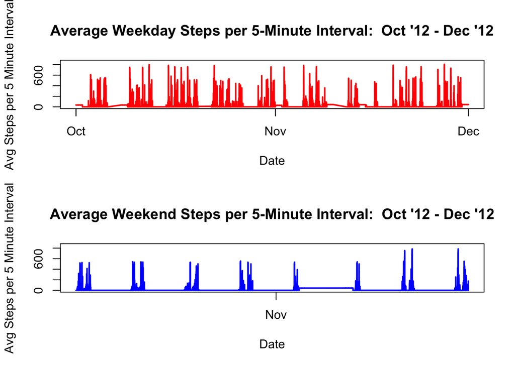

```r
# Set the plotting parameters for 2 rows and 1 column
par(mfrow = c(2,1))

# Plot for weekdays
plot(df3weekdays$newDate, df3weekdays$steps,
     type = "l",
     col = "red",
     lwd = 2,
     main = "Average Weekday Steps per 5-Minute Interval:  Oct '12 - Dec '12",
     xlab ="Date",
     ylab = "Avg Steps per 5 Minute Interval",
     ylim = c(0,850))

# Plot for weekends
plot(df3weekends$newDate, df3weekends$steps,
     type = "l",
     col = "blue",
     lwd = 2,
     main = "Average Weekend Steps per 5-Minute Interval:  Oct '12 - Dec '12",
     xlab ="Date",
     ylab = "Avg Steps per 5 Minute Interval",
     ylim = c(0,850))
```

**This completes my first real markdown document.**

*May you be happy. May you be free from suffering.*